# Linear Regression Project

Congratulations! You just got some contract work with an Ecommerce company based in New York City that sells clothing online but they also have in-store style and clothing advice sessions. Customers come in to the store, have sessions/meetings with a personal stylist, then they can go home and order either on a mobile app or website for the clothes they want.

The company is trying to decide whether to focus their efforts on their mobile app experience or their website. They've hired you on contract to help them figure it out! Let's get started!

Just follow the steps below to analyze the customer data (it's fake, don't worry I didn't give you real credit card numbers or emails).

## Imports

**Import pandas, numpy, matplotlib,and seaborn. Then set %matplotlib inline (You'll import sklearn as you need it.)**

```python
import pandas as pd
import numpy as np
import matplotlib.pyplot as plt
import seaborn as sns
sns.set_style('whitegrid')
```

```python
%matplotlib inline
```

## Get the Data

We'll work with the Ecommerce Customers csv file from the company. It has Customer info, such as Email, Address, and their color Avatar. Then it also has numerical value columns:

- Avg. Session Length: Average session of in-store style advice sessions.
- Time on App: Average time spent on App in minutes
- Time on Website: Average time spent on Website in minutes
- Length of Membership: How many years the customer has been a member.

**Read in the Ecommerce Customers csv file as a DataFrame called customers.**

```python
customers = pd.read_csv('Ecommerce Customers')
```

**Check the head of customers, and check out its info() and describe() methods.**

```python
customers.head()
```

|  | Email | Address | Avatar | Avg. Session Length | Time on App | Time on Website | Length of Membership | Yearly Amount Spent |
| --- | --- | --- | --- | --- | --- | --- | --- | --- |
| 0 | mstephenson@fernandez.com | 835 Frank Tunnel\nWrightmouth, MI 82180-9605 | Violet | 34.497268 | 12.655651 | 39.577668 | 4.082621 | 587.951054 |
| 1 | hduke@hotmail.com | 4547 Archer Common\nDiazchester, CA 06566-8576 | DarkGreen | 31.926272 | 11.109461 | 37.268959 | 2.664034 | 392.204933 |
| 2 | pallen@yahoo.com | 24645 Valerie Unions Suite 582\nCobbborough, D... | Bisque | 33.000915 | 11.330278 | 37.110597 | 4.104543 | 487.547505 |
| 3 | riverarebecca@gmail.com | 1414 David Throughway\nPort Jason, OH 22070-1220 | SaddleBrown | 34.305557 | 13.717514 | 36.721283 | 3.120179 | 581.852344 |
| 4 | mstephens@davidson-herman.com | 14023 Rodriguez Passage\nPort Jacobville, PR 3... | MediumAquaMarine | 33.330673 | 12.795189 | 37.536653 | 4.446308 | 599.406092 |

```python
customers.describe()
```

|  | Avg. Session Length | Time on App | Time on Website | Length of Membership | Yearly Amount Spent |
| --- | --- | --- | --- | --- | --- |
| count | 500.000000 | 500.000000 | 500.000000 | 500.000000 | 500.000000 |
| mean | 33.053194 | 12.052488 | 37.060445 | 3.533462 | 499.314038 |
| std | 0.992563 | 0.994216 | 1.010489 | 0.999278 | 79.314782 |
| min | 29.532429 | 8.508152 | 33.913847 | 0.269901 | 256.670582 |
| 25% | 32.341822 | 11.388153 | 36.349257 | 2.930450 | 445.038277 |
| 50% | 33.082008 | 11.983231 | 37.069367 | 3.533975 | 498.887875 |
| 75% | 33.711985 | 12.753850 | 37.716432 | 4.126502 | 549.313828 |
| max | 36.139662 | 15.126994 | 40.005182 | 6.922689 | 765.518462 |

```python
customers.info()
```

```
<class 'pandas.core.frame.DataFrame'>
RangeIndex: 500 entries, 0 to 499
Data columns (total 8 columns):
 #   Column                Non-Null Count  Dtype
---  ------                --------------  -----
 0   Email                 500 non-null    object
 1   Address               500 non-null    object
 2   Avatar                500 non-null    object
 3   Avg. Session Length   500 non-null    float64
 4   Time on App           500 non-null    float64
 5   Time on Website       500 non-null    float64
 6   Length of Membership  500 non-null    float64
 7   Yearly Amount Spent   500 non-null    float64
dtypes: float64(5), object(3)
memory usage: 31.4+ KB
```

## Exploratory Data Analysis

**Let's explore the data!**

For the rest of the exercise we'll only be using the numerical data of the csv file.

**Use seaborn to create a jointplot to compare the Time on Website and Yearly Amount Spent columns. Does the correlation make sense?**

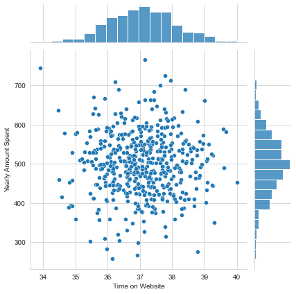

```python
sns.jointplot(x='Time on Website', y='Yearly Amount Spent', data=customers)
```

**Do the same but with the Time on App column instead.**

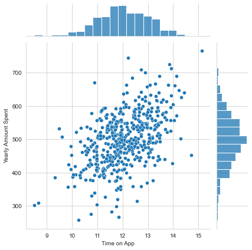

```python
sns.jointplot(x='Time on App', y='Yearly Amount Spent', data=customers)
```

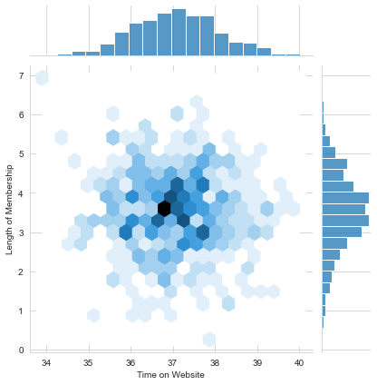

```python
sns.jointplot(x='Time on Website', y='Length of Membership', data=customers, kind='hex')
```

**Let's explore these types of relationships across the entire data set. Use pairplot to recreate the plot below.(Don't worry about the the colors)**

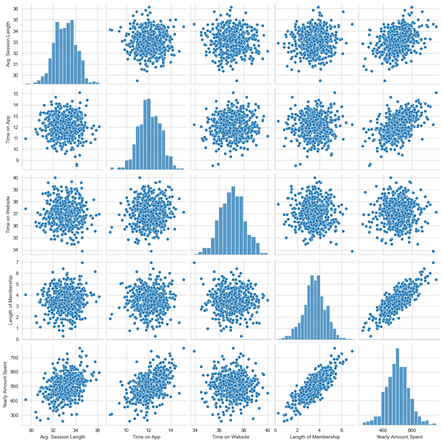

```python
sns.pairplot(customers)
```

**Based off this plot what looks to be the most correlated feature with Yearly Amount Spent?**

```python
# Length of Membership
```

**Create a linear model plot (using seaborn's lmplot) of Yearly Amount Spent vs. Length of Membership.**

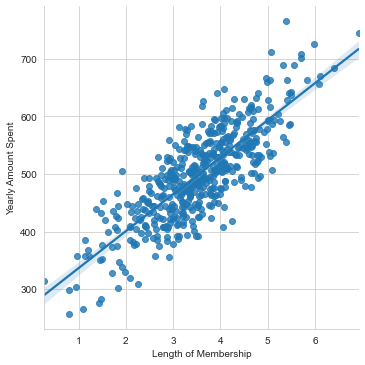

```python
sns.lmplot(x='Length of Membership', y='Yearly Amount Spent', data=customers)
```

## Training and Testing Data

Now that we've explored the data a bit, let's go ahead and split the data into training and testing sets. **Set a variable X equal to the numerical features of the customers and a variable y equal to the "Yearly Amount Spent" column.**

```python
customers.columns
```

```
Index(['Email', 'Address', 'Avatar', 'Avg. Session Length', 'Time on App',
       'Time on Website', 'Length of Membership', 'Yearly Amount Spent'],
      dtype='object')
```

```python
X = customers[['Avg. Session Length', 'Time on App', 'Time on Website', 'Length of Membership']]
X
```

|  | Avg. Session Length | Time on App | Time on Website | Length of Membership |
| --- | --- | --- | --- | --- |
| 0 | 34.497268 | 12.655651 | 39.577668 | 4.082621 |
| 1 | 31.926272 | 11.109461 | 37.268959 | 2.664034 |
| 2 | 33.000915 | 11.330278 | 37.110597 | 4.104543 |
| 3 | 34.305557 | 13.717514 | 36.721283 | 3.120179 |
| 4 | 33.330673 | 12.795189 | 37.536653 | 4.446308 |
| ... | ... | ... | ... | ... |
| 495 | 33.237660 | 13.566160 | 36.417985 | 3.746573 |
| 496 | 34.702529 | 11.695736 | 37.190268 | 3.576526 |
| 497 | 32.646777 | 11.499409 | 38.332576 | 4.958264 |
| 498 | 33.322501 | 12.391423 | 36.840086 | 2.336485 |
| 499 | 33.715981 | 12.418808 | 35.771016 | 2.735160 |

500 rows × 4 columns

```python
y = customers['Yearly Amount Spent']
y
```

```
0      587.951054
1      392.204933
2      487.547505
3      581.852344
4      599.406092
          ...
495    573.847438
496    529.049004
497    551.620145
498    456.469510
499    497.778642
Name: Yearly Amount Spent, Length: 500, dtype: float64
```

**Use model_selection.train_test_split from sklearn to split the data into training and testing sets. Set test_size=0.3 and random_state=101**

```python
from sklearn.model_selection import train_test_split
```

```python
X_train, X_test, y_train, y_test = train_test_split(X, y, test_size=0.3, random_state=101)
```

## Training the Model

Now its time to train our model on our training data!

**Import LinearRegression from sklearn.linear_model**

```python
from sklearn.linear_model import LinearRegression
```

**Create an instance of a LinearRegression() model named lm.**

```python
lm = LinearRegression()
```

**Train/fit lm on the training data.**

```python
lm.fit(X_train, y_train)
```

```
LinearRegression()
```

**Print out the coefficients of the model**

```python
a = str(lm.coef_)
a
```

```
'[25.98154972 38.59015875  0.19040528 61.27909654]'
```

```python
print('Coefficients: \n' + a)
```

```
Coefficients:
[25.98154972 38.59015875  0.19040528 61.27909654]
```

## Predicting Test Data

Now that we have fit our model, let's evaluate its performance by predicting off the test values!

**Use lm.predict() to predict off the X_test set of the data.**

```python
lm.predict(X_test)
```

```
array([456.44186104, 402.72005312, 409.2531539 , 591.4310343 ,
       590.01437275, 548.82396607, 577.59737969, 715.44428115,
       473.7893446 , 545.9211364 , 337.8580314 , 500.38506697,
       552.93478041, 409.6038964 , 765.52590754, 545.83973731,
       693.25969124, 507.32416226, 573.10533175, 573.2076631 ,
       397.44989709, 555.0985107 , 458.19868141, 482.66899911,
       559.2655959 , 413.00946082, 532.25727408, 377.65464817,
       535.0209653 , 447.80070905, 595.54339577, 667.14347072,
       511.96042791, 573.30433971, 505.02260887, 565.30254655,
       460.38785393, 449.74727868, 422.87193429, 456.55615271,
       598.10493696, 449.64517443, 615.34948995, 511.88078685,
       504.37568058, 515.95249276, 568.64597718, 551.61444684,
       356.5552241 , 464.9759817 , 481.66007708, 534.2220025 ,
       256.28674001, 505.30810714, 520.01844434, 315.0298707 ,
       501.98080155, 387.03842642, 472.97419543, 432.8704675 ,
       539.79082198, 590.03070739, 752.86997652, 558.27858232,
       523.71988382, 431.77690078, 425.38411902, 518.75571466,
       641.9667215 , 481.84855126, 549.69830187, 380.93738919,
       555.18178277, 403.43054276, 472.52458887, 501.82927633,
       473.5561656 , 456.76720365, 554.74980563, 702.96835044,
       534.68884588, 619.18843136, 500.11974127, 559.43899225,
       574.8730604 , 505.09183544, 529.9537559 , 479.20749452,
       424.78407899, 452.20986599, 525.74178343, 556.60674724,
       425.7142882 , 588.8473985 , 490.77053065, 562.56866231,
       495.75782933, 445.17937217, 456.64011682, 537.98437395,
       367.06451757, 421.12767301, 551.59651363, 528.26019754,
       493.47639211, 495.28105313, 519.81827269, 461.15666582,
       528.8711677 , 442.89818166, 543.20201646, 350.07871481,
       401.49148567, 606.87291134, 577.04816561, 524.50431281,
       554.11225704, 507.93347015, 505.35674292, 371.65146821,
       342.37232987, 634.43998975, 523.46931378, 532.7831345 ,
       574.59948331, 435.57455636, 599.92586678, 487.24017405,
       457.66383406, 425.25959495, 331.81731213, 443.70458331,
       563.47279005, 466.14764208, 463.51837671, 381.29445432,
       411.88795623, 473.48087683, 573.31745784, 417.55430913,
       543.50149858, 547.81091537, 547.62977348, 450.99057409,
       561.50896321, 478.30076589, 484.41029555, 457.59099941,
       411.52657592, 375.47900638])
```

```python
predictions = lm.predict(X_test)
```

**Create a scatterplot of the real test values versus the predicted values.**

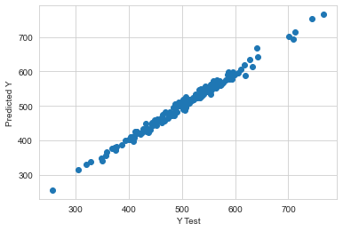

```python
plt.scatter(x=y_test, y=predictions)
plt.xlabel('Y Test')
plt.ylabel('Predicted Y')
```

## Evaluating the Model

Let's evaluate our model performance by calculating the residual sum of squares and the explained variance score (R^2).

**Calculate the Mean Absolute Error, Mean Squared Error, and the Root Mean Squared Error. Refer to the lecture or to Wikipedia for the formulas**

```python
from sklearn import metrics
```

```python
# residual sum of squares

print('MAE:', metrics.mean_absolute_error(y_test, predictions))
print('MSE:', metrics.mean_squared_error(y_test, predictions))
print('RMSE:', np.sqrt(metrics.mean_squared_error(y_test, predictions)))
```

```
MAE: 7.22814865343083
MSE: 79.8130516509745
RMSE: 8.933815066978637
```

```python
# explained variance score (R^2)

metrics.explained_variance_score(y_test, predictions)
```

```
0.9890771231889607
```

## Residuals

You should have gotten a very good model with a good fit. Let's quickly explore the residuals to make sure everything was okay with our data.

**Plot a histogram of the residuals and make sure it looks normally distributed. Use either seaborn distplot, or just plt.hist().**

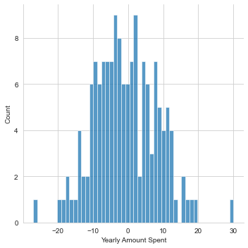

```python
sns.displot((y_test-predictions), bins=50)
```

## Conclusion

We still want to figure out the answer to the original question, do we focus our efforst on mobile app or website development? Or maybe that doesn't even really matter, and Membership Time is what is really important. Let's see if we can interpret the coefficients at all to get an idea.

**Recreate the dataframe below.**

```python
coeffdf = pd.DataFrame(lm.coef_, X.columns, columns=['Coeffecient'])
coeffdf
```

|  | Coeffecient |
| --- | --- |
| Avg. Session Length | 25.981550 |
| Time on App | 38.590159 |
| Time on Website | 0.190405 |
| Length of Membership | 61.279097 |

**How can you interpret these coefficients?**

```python
# Interpreting the coefficients:
```

**Do you think the company should focus more on their mobile app or on their website?**

```python
# The coefficients point towards focusing more on the app. However the website could also benefit from more focused
# development. The Length of Membership however has a more substantial increase associated to it.
# The data can be further explored to look at the relationship between the Length of Membership
# and the Time on App & Time on Website, for further insight.
```

```python
# Exploring a Length of Membership to Time on App & Time on Website
```

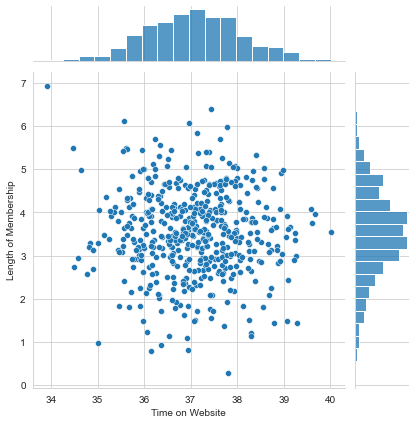

```python
sns.jointplot(x='Time on Website', y='Length of Membership', data=customers)
```

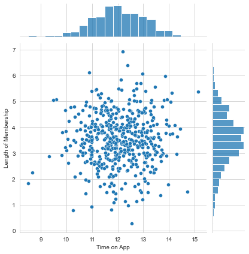

```python
sns.jointplot(x='Time on App', y='Length of Membership', data=customers)
```

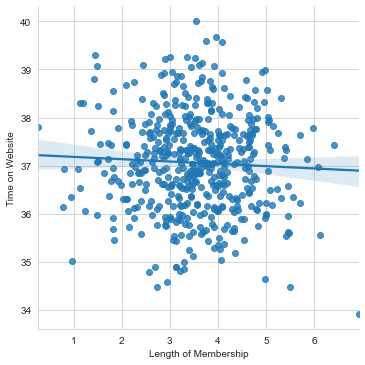

```python
sns.lmplot(x='Length of Membership', y='Time on Website', data=customers)
```

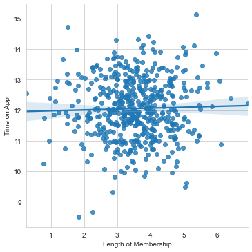

```python
sns.lmplot(x='Length of Membership', y='Time on App', data=customers)
```

```python
X = customers[['Time on App', 'Time on Website']]
```

```python
y = customers['Length of Membership']
```

```python
X_train, X_test, y_train, y_test = train_test_split(X, y, test_size=0.3, random_state=101)
```

```python
lm.fit(X_train, y_train)
```

```
LinearRegression()
```

```python
print('Coefficients: \n', lm.coef_)
```

```
Coefficients:
 [ 0.03719133 -0.05340659]
```

```python
predictions = lm.predict(X_test)
```

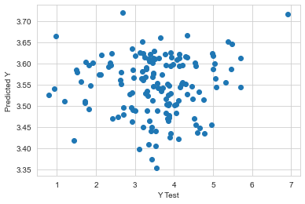

```python
plt.scatter(x=y_test, y=predictions)
plt.xlabel('Y Test')
plt.ylabel('Predicted Y')
```

```python
print('MAE:', metrics.mean_absolute_error(y_test, predictions))
print('MSE:', metrics.mean_squared_error(y_test, predictions))
print('RMSE:', np.sqrt(metrics.mean_squared_error(y_test, predictions)))
```

```
MAE: 0.7799765976371756
MSE: 1.067428331522678
RMSE: 1.033164232599386
```

```python
metrics.explained_variance_score(y_test, predictions)
```

```
0.002767104782280372
```

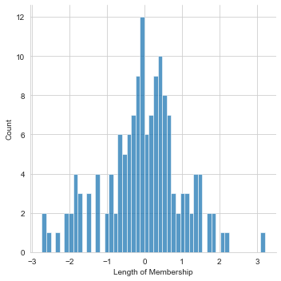

```python
sns.displot((y_test-predictions), bins=50)
```

```python
coeffdf = pd.DataFrame(lm.coef_, X.columns, columns=['Coeffecient'])
coeffdf
```

|  | Coeffecient |
| --- | --- |
| Time on App | 0.037191 |
| Time on Website | -0.053407 |

## Great Job!

Congrats on your contract work! The company loved the insights! Let's move on.